# STAA57 Assignment

# 7.2 Bootstrapping Analysis for Mean Estimation

The code below is to conduct bootstrapping to estimate the mean of the ‘ratio’ variable in the ‘d_ratio’ dataset. The function ‘boot_function2’ is defined to repeatedly sample with replacement from the ‘ratio’ variable, calculate the mean of the sampled data, and return it. The code then performs bootstrapping by calling ‘boot_function2’ 1000 times and calculates the 5th percentile of the resulting output vector.

```
##         5%
## 0.04499505
```

**From the above consequence:**

```
The output indicates that the 5th percentile of the bootstrapped means of the 'ratio' variable is approximately 0.045. This suggests that there is a 5% probability that the true mean of the 'ratio' variable in the population is lower than or equal to 0.045, based on the bootstrapped samples.

Therefore, the conclusion is that the estimated mean of the 'ratio' variable in the dataset 'd_ratio' is likely to be greater than 0.045, with 95% confidence. This information can be valuable for understanding the central tendency of the 'ratio' variable and making inferences about the population mean based on the sampled data.
```

## 8 Regression analysis

# 8.1 random forest

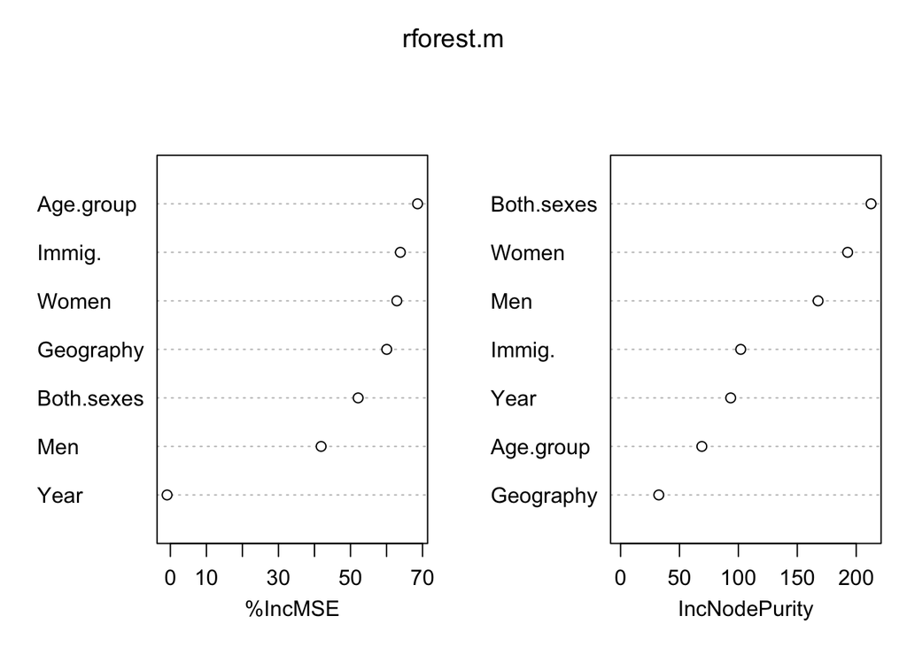

```
## [1] 0.1241425
```

# 8.2 Linear regression

```
##
## Call:
## lm(formula = Both.sexes ~ Year, data = d_table1)
##
## Residuals:
##     Min      1Q  Median      3Q     Max
## -1128.6  -995.6   -50.5  1027.9  1121.4
##
## Coefficients:
##              Estimate Std. Error t value Pr(>|t|)
## (Intercept) -52594.18  100098.05  -0.525    0.604
## Year            27.28      49.74   0.549    0.588
##
## Residual standard error: 1061 on 26 degrees of freedom
## Multiple R-squared:  0.01144,    Adjusted R-squared:  -0.02658
## F-statistic: 0.3009 on 1 and 26 DF,  p-value: 0.588
```

# 9 Summary of Research